# ProjectR

```r
ggsave("PCA_Method_Mouse_Projected_onto_Human.pdf", projected_PCA)
```

```r
#Alluvial Plot
#need a character vector of annotations for alluvial
#mouse_GO_list <- mouse_symbol_GO$ONTOLOGY
#human_GO_t <- t(human_symbol_data_GO)
#alluvial <- alluvialMat(projection = human_NMF, annotations = human_info$BMI, plot = TRUE)
#alluvial

#ggalluvial <- ggplot(data = human_symbol_data_GO,
#       aes(axis1 = , axis2 = PrePost,
#           y = Pattern_1)) +
#  scale_x_discrete(limits = c("Sample", "PrePost Exercise"), expand = c(.2, .05)) +
#  xlab(" ") +
#  geom_alluvium(aes(fill = BMI)) +
#  geom_stratum() +
#  geom_text(stat = "stratum", aes(label = after_stat(stratum))) +
#  theme_minimal() +
#  ggtitle(" ")

#ggalluvial
```

**ProjectR Clustering Method**  
There’s 2 methods: cluster2pattern finds correlation of each gene’s expression by mean of cluster to define continuous weights. Then intersector tests significant overlap between 2 clustering objects. For these purposes, I think cluster2pattern is better for finding what we want (differences between clusters rather than overlaps). Requires a clustering object first.

```r
#TOP 50 DIFFERENTIALLY EXPRESSED GENES
#error "the standard deviation is zero" for cluster2pattern
#checking standard deviation for each gene
stdevs <- apply(conv_mouse, 1, sd)
mouse_stdev <- cbind(conv_mouse, stdevs)
mouse_stdev <- slice_max(mouse_stdev, order_by = stdevs, n = 50)
mouse_top50 <- mouse_stdev[,-17]
write.csv2(mouse_top50, file = "Mouse_Top50_DEG.csv", sep = ",")
```

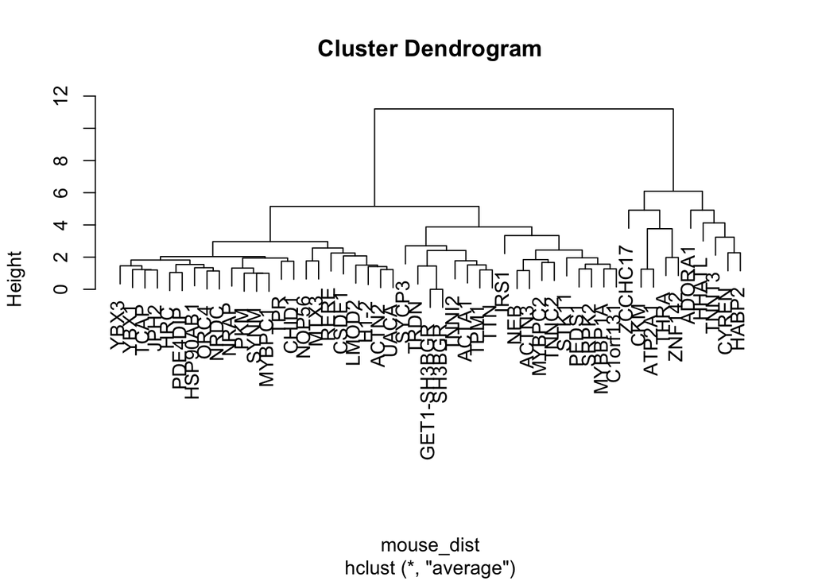

```r
library(fpc)
#pamk: partitioning around medoids clustering with the number of clusters estimated by optimum average silhouette width
#part_clust_mouse <- pamk(stdevs, scaling = TRUE)
#plot(part_clust_mouse$pamobject)

#  Hierarchical Clustering
mouse_dist <- dist(mouse_top50, method = "euclidean") # distance matrix
hclust_fit <- hclust(mouse_dist, method="average")
plot(hclust_fit) # display dendrogram
```

```r
#looks like 3 clusters would be best
```

```r
#  Hierarchical Clustering with Bootstrapped p values
library(pvclust)
#pvclust() provides p-values for hierarchical clustering based on multiscale bootstrap resampling-clusters that are highly supported by the data will have large p values.
#pvclust clusters columns, not rows: transpose your data before using
fit <- pvclust(mouse_top50, method.hclust="average",
   method.dist="euclidean")
```

```
## Bootstrap (r = 0.49)... Done.
## Bootstrap (r = 0.59)... Done.
## Bootstrap (r = 0.69)... Done.
## Bootstrap (r = 0.78)... Done.
## Bootstrap (r = 0.88)... Done.
## Bootstrap (r = 1.0)... Done.
## Bootstrap (r = 1.1)... Done.
## Bootstrap (r = 1.2)... Done.
## Bootstrap (r = 1.29)... Done.
## Bootstrap (r = 1.39)... Done.
```

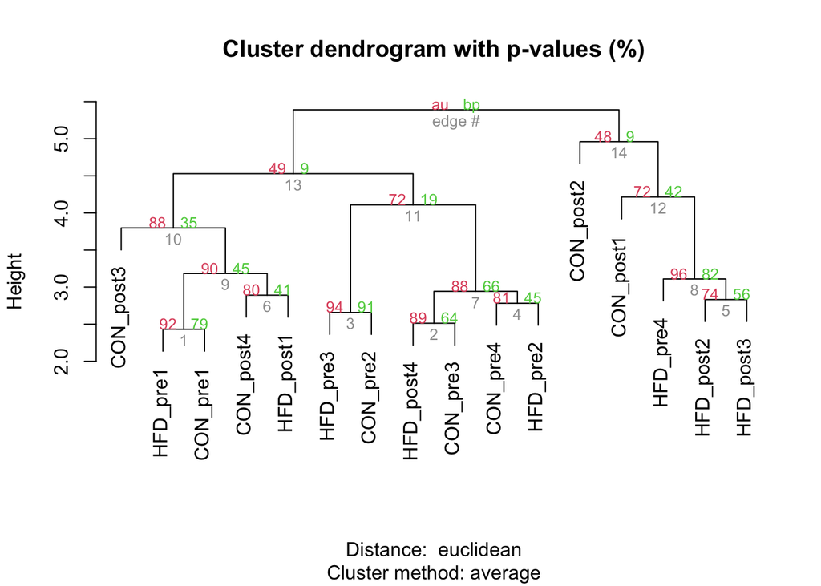

```r
hclust_dendro_sig <- plot(fit) # dendogram with p values
```

```r
hclust_dendro_sig
```

```r
# add rectangles around groups highly supported by the data
#pvrect(fit, alpha=.95)
pdf(file = "Mouse_Hclust_Dendrogram.pdf", hclust_dendro_sig)

#clusterplotR... what is this/how to use this/should I use this?
#mouse_clusterplotr <- clusterPlotR(mouse_stdev, hclust_fit, NC = 3)
```

Output of the cluster2pattern function is a pclust class object; specifically, a matrix of genes (rows) by clusters (columns). A gene’s value outside of its assigned cluster is zero. For the cluster containing a given gene, the gene’s value is the corelation of the gene’s expression to the mean of that cluster.

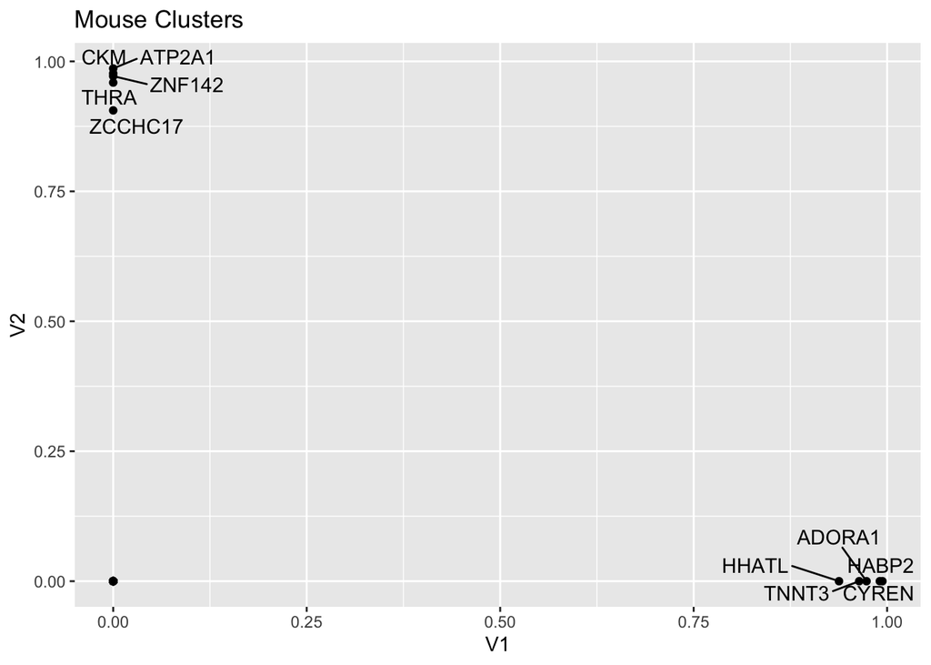

```r
#function to extract genes highly correlated with gene or reference expression pattern
#mouse_corr <- correlateR(genes = row.names(human_symbol_data), dat = mouse_stdev)
#the standard deviation is zero

#output of the cluster2pattern function is a pclust class object; specifically, a matrix of
#genes (rows) by clusters (columns). A gene’s value outside of its assigned cluster is zero. For
#the cluster containing a given gene, the gene’s value is the corelation of the gene’s expression
#to the mean of that cluster.
mouse_clusters <- cluster2pattern(hclust_fit, NP = 3, Data = mouse_stdev)

cluster_plot <- ggplot(as.data.frame(mouse_clusters), aes(x = V1, y = V2, label = rownames(mouse_clusters))) + geom_point() + ggtitle("Mouse Clusters") + geom_text_repel()
cluster_plot
```

```r
#join these genes to their GO terms?
#mouse_clusters_GO <- left_join()
#mouse_clusterplot <- clusterPlotR(cdata = mouse_top50, cls = hclust_fit, NC = 1, mouse_info$Exercise)
#Error in matrix(ncol = dim(cData)[2], nrow = length(cls1)) : non-numeric matrix extent
```

Projecting mouse clusters onto human data

```r
#need to use the top 50 genes from mouse DE to pull those genes from human and then project cluster object from cluster2pattern onto human data
top50_list <- rownames_to_column(mouse_top50, var = "SYMBOL")
human_list <- rownames_to_column(human_symbol_data_GO, var = "SYMBOL")
top50_list <- semi_join(human_list, top50_list, by = "SYMBOL")
human_top50 <- column_to_rownames(top50_list, var = "SYMBOL")
human_top50 <- human_top50[,5:62]
human_top50 <- as.matrix(human_top50)
```

```r
cluster_projection <- projectR(human_top50, loadings = mouse_clusters, full = TRUE, dataNames = rownames(human_top50))
```

```
## [1] "51 row names matched between data and loadings"
## [1] "Updated dimension of data: 51 58"
```

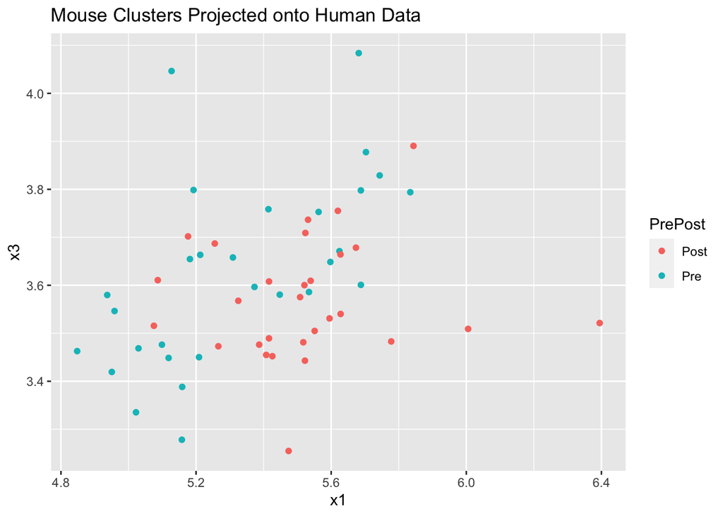

```r
#combining projection with metadata and preparing for PCA
cluster_projection_t <- t(cluster_projection[[1]])
cluster_projection_df <- cbind(cluster_projection_t, human_meta)
cluster_projection_plot <- ggplot(cluster_projection_df, aes(x = x1, y = x3, colour = PrePost)) + geom_point() + ggtitle("Mouse Clusters Projected onto Human Data")
cluster_projection_plot
```

```r
ggsave("Mouse_Clusters_Projection.pdf", cluster_projection_plot)
```

## Using Differentially Expressed Genes for Functional Enrichment Analysis

**AnnotationDbi for DESeq2 Mouse Results**

```r
#Pull DESeq2 results for LFC and P-values, get rid of decimals in ensembl ID's
mouse_de <- cbind(LFC = mouse_res$log2FoldChange, Pval = mouse_res$pvalue)
row.names(mouse_de) <- row.names(mouse_res)
rownames(mouse_de) <- sub("\\..*", "", rownames(mouse_de))
mouse_de_df <- mouse_de %>% as.data.frame() %>% rownames_to_column(., "ENSEMBL")
```

```r
#Join annotations to DE gene list
mouse_symbol_de <- inner_join(mouse_anno, mouse_de_df, by = "ENSEMBL")
mouse_symbol_GO_de <- column_to_rownames(mouse_symbol_de, var = "SYMBOL")
#This table has ensembl gene ID's, GO info, differential expression and p-values
write.csv(mouse_symbol_GO_de, "Mouse_DE_GO.csv")
#Only need LFC and p-values for FEA
mouse_symbol_de <- mouse_symbol_GO_de[,c(5,6)]
```

```r
#Mouse symbols need to be converted to human symbols for downstream analysis
#Use convertMouseGeneList to convert to human genes
#mouse_to_human_genes_de <- convertMouseGeneList(mouse_anno$SYMBOL)
#conv_mouse_de <- mouse_symbol_de %>% rownames_to_column(., var = "MGI.symbol") %>% #left_join(., mouse_to_human_genes_ge, by = "MGI.symbol")

#determine non-NA genes
#non_na_mouse_de <- which(is.na(conv_mouse_de$HGNC.symbol) == FALSE)

#return only the genes with annotations using indices
#conv_mouse_de <- conv_mouse_de[non_na_mouse_de, ]

#determine indices for non-duplicated genes
#no_dups_mouse_de <- which(duplicated(conv_mouse_de$HGNC.symbol) == FALSE)

#return only non-dup genes using indices
#conv_mouse_de <- conv_mouse_de[no_dups_mouse_de, ]
#rownames(conv_mouse_de) <- NULL
#conv_mouse_de <- conv_mouse_de %>% as.data.frame() %>% column_to_rownames(., var = "HGNC.symbol")
#conv_mouse_de <- conv_mouse_de[,c(2:17)]
```